# An Analysis of Different Outlier Detection Methods

Alex Khater, Tina Liu

2020/1/23

**Introduction:**

The goal of this research project is to compare the outputs of different methods of outlier detection on a variety of different datasets and will attempt to draw conclusions about the relative conservativeness of a given outlier test on data sets of certain distributions and sizes.

We randomly selected 30 real-world datasets from various experiments and studies and inserted 9 control of each size: Small (x<70), Medium(70<x<500), Large(500<x) and of the 3 common distribution types of the sample: Right Skew, Normal, and Left Skew. We ran 5 Outlier tests on them (R functions will be shown below) :

```r
chi_square <- function (x, pvalue = 0.03, opposite = FALSE) {
    x <- sort(x[complete.cases(x)])
    variance <- var(x)
    mea <- mean(x)
    n <- length(x)
    i <- 1
    pval <- chisq.out.test(x, opposite = opposite)$p.value
    num <- -1
    while(pval < pvalue) {
      if (xor(((x[n] - mea) < (mea - x[i])), opposite)) {
        alt = paste("lowest value", x[i], "is an outlier")
        chi <- (mea - x[i])^2/variance
        i <- i + 1
        }
      else {
        alt = paste("highest value", x[n], "is an outlier")
        chi <- (x[n] - mea)^2/variance
        n <- n - 1
        }
      pval <- 1 - pchisq(chi, 1)
      print(alt)
      num <- num + 1
    }
    print(num)
}
```

Cook’s Distance: This test measures the Cook’s Distance of each point, a measure of influence, and isolates any point with more than 4 times the mean cook’s distance as an outlier.

```r
cook_distance <- function(lm) {
  cooksd <- cooks.distance(lm)
  k <- 4*mean(cooksd)
  data <- data.frame(id=as.character(1:length(cooksd)),
                  value=cooksd,
                  stringsAsFactors=F)
  data %>%
    mutate(id = seq.int(nrow(data))) %>%
    mutate(outlier = if_else(value >= k, "yes", "no")) %>%
    filter(outlier == "yes")
}
```

1.5 IQR: This uses the interquartile range (Q3 - Q1) and creates a boundary 1.5 * IQR below Q1 and 1.5* IQR above Q3 to isolate outliers.

```r
IQR_test <- function(data, num, v) {
  str <- unname(quantile(num, probs = c(0.25, 0.75), na.rm = TRUE)[c("25%", "75%")])
  iqr <- str[2] - str[1]
  q1 <- str[1] - 1.5*iqr
  q3 <- str[2] + 1.5*iqr
  data %>%
    mutate(id = seq.int(nrow(data))) %>%
    select(id, v) %>%
    rename("value" = v) %>%
    mutate(outlier = if_else(value >= q3 | value <= q1, "yes", "no")) %>%
    filter(outlier == "yes")
}
```

2.5 SD: This uses the standard deviation to create a boundary 2.5 standard deviations above and below the mean.

```r
sd_test <- function(data, num, v) {
  t1 <- mean(num) + 2.5*sd(num)
  t2 <- mean(num) - 2.5*sd(num)
  data %>%
    mutate(id = seq.int(nrow(data))) %>%
    select(id, v) %>%
    rename("value" = v) %>%
    mutate(outlier = if_else(value >= t1 | value <= t2, "yes", "no")) %>%
    filter(outlier == "yes")
}
```

Bonferroni: A test that comes in the outliers R package, it analyzes the most extreme value, extracts a p-value and applies the Bonferroni correction to create a p-value adjusted for the sample size.

Examples of each test:

Fig. 1: Example dataset:

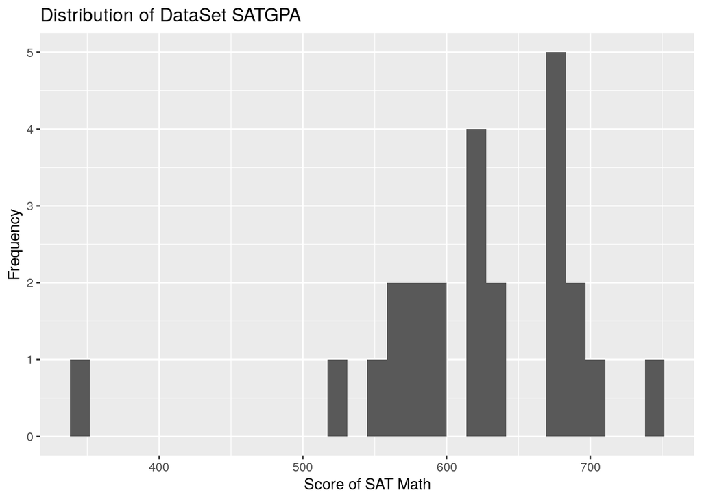

And here are the results of different outlier tests on the dataset:

```r
chi_square(SATGPA$MathSAT, 0.03)
```

```
## [1] "lowest value 350 is an outlier"
## [1] "highest value 750 is an outlier"
## [1] 1
```

```r
cook_distance(D6)
```

```
##   id     value outlier
## 1 13 0.5164572     yes
```

```r
IQR_test(SATGPA, SATGPA$MathSAT, "MathSAT")
```

```
##   id value outlier
## 1 13   350     yes
```

```r
sd_test(SATGPA, SATGPA$MathSAT, "MathSAT")
```

```
##   id value outlier
## 1 13   350     yes
```

```r
outlierTest(D6, n.max = Inf)
```

```
##     rstudent unadjusted p-value Bonferroni p
## 13 -4.847424         7.6281e-05    0.0018308
```

**Post-Experiment Data:**

Fig. 2:

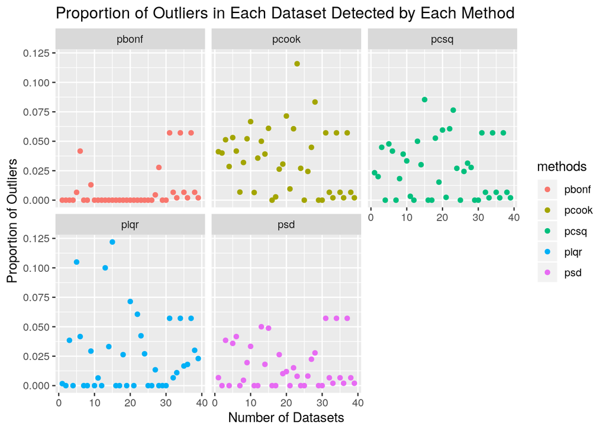

```r
record %>%
  gather(
    key = "methods",
    value = "proportion",
    pcsq, pcook, piqr, psd, pbonf
    ) %>%
  ggplot(aes(x = id, y = proportion, color = methods)) +
  geom_point() +
  facet_wrap(~methods) +
  ylab("Proportion of Outliers") +
  xlab("Number of Datasets") +
  ggtitle("Proportion of Outliers in Each Dataset Detected by Each Method")
```

Fig. 3:

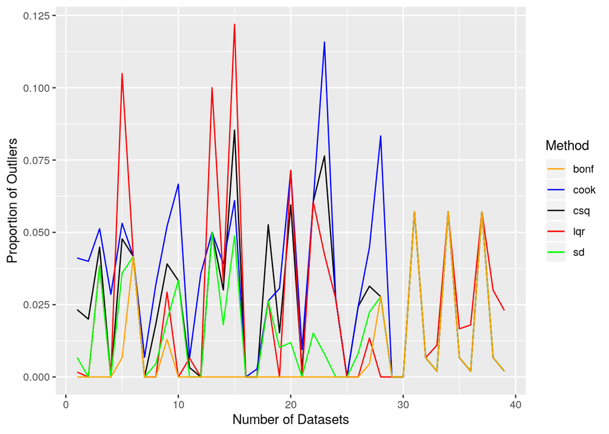

Fig. 4:

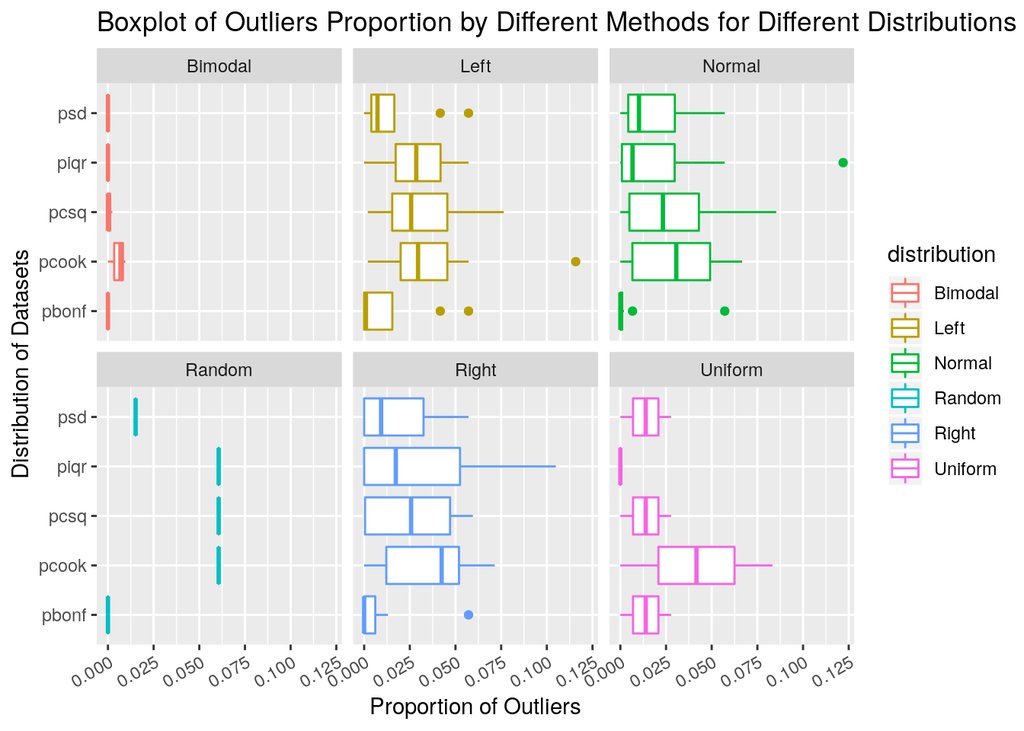

```r
record %>%
  gather(
    key = "methods",
    value = "proportion",
    pcsq, pcook, piqr, psd, pbonf
    ) %>%
  ggplot(aes(x = methods, y = proportion, color = distribution)) +
  geom_boxplot() +
  facet_wrap(~distribution) +
  coord_flip() +
  theme(axis.text.x = element_text(angle=30, hjust=1)) +
  ylab("Proportion of Outliers") +
  xlab("Distribution of Datasets") +
  ggtitle("Boxplot of Outliers Proportion by Different Methods for Different Distributions")
```

Fig. 6:

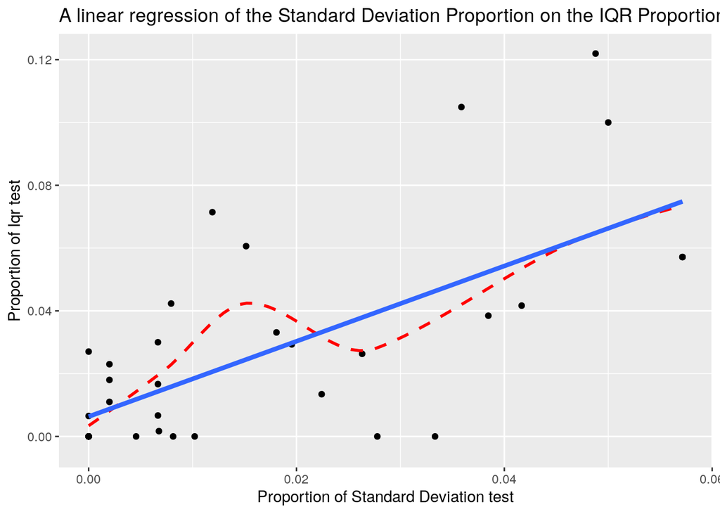

Fig. 7:

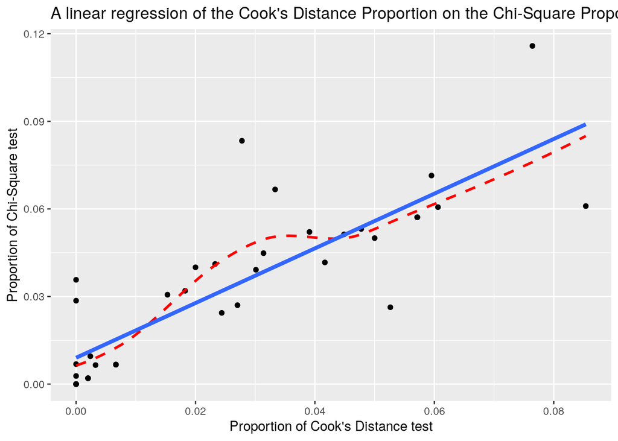

Fig. 8 :

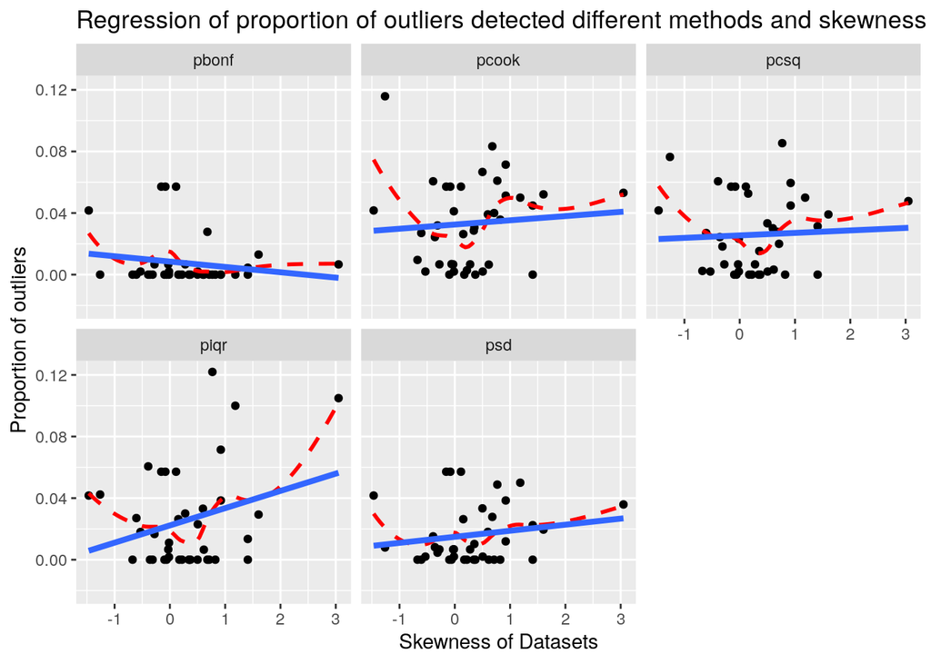

ANOVA on Proportion Methods:

```
##              Df  Sum Sq  Mean Sq F value   Pr(>F)
## methods       4 0.01572 0.003930  14.506 4.68e-10 ***
## setName      38 0.07586 0.001996   7.369  < 2e-16 ***
## Residuals   152 0.04118 0.000271
## ---
## Signif. codes:  0 '***' 0.001 '**' 0.01 '*' 0.05 '.' 0.1 ' ' 1
```

There is evidence to show that the means are significantly different.

ANOVA Comparing Proportions of Outliers detected by Chi Square and IQR:

```
##             Df  Sum Sq   Mean Sq F value   Pr(>F)
## methods      1 0.00000 0.0000034   0.017    0.896
## setName     38 0.05587 0.0014704   7.492 4.69e-09 ***
## Residuals   38 0.00746 0.0001963
## ---
## Signif. codes:  0 '***' 0.001 '**' 0.01 '*' 0.05 '.' 0.1 ' ' 1
```

There is no evidence to suggest that the means are significantly different.

**Conclusion:**

After observing the data we can see:

The means of the proportions: (Cook’s, Chi-Square, IQR, SD, Bonferroni)

```
## [1] 0.03332991
```

```
## [1] 0.02594615
```

```
## [1] 0.0255275
```

```
## [1] 0.0160084
```

```
## [1] 0.007462108
```

As seen The ANOVA tests, we know that the difference between the mean proportions of methods are significant. We can conclude that these outlier tests work far from identically. The Cook’s Distance seems to find the most outliers per dataset whereas the Bonferroni seems to find the least.

When accounting for Skewness, there are noticable increases in proportion detected for the IQR method when the skewness of dataset is larger and positive,right-skewed. In fact, nearly all regression lines in Fig. 8 have positive slopes, meaning the proportion of outliers detected rises with right skewness, the IQR having the largest slope. The Bonferroni Regression line has a slightly negative slope, making it find more outliers with left skewed dataset.

Some of these results match what one would expect. The IQR and Standard Deviation tests should be similar for normal distributions. The IQR has a much larger outlier detection proportion on skew distribution because these distributions would affect the detection apparatus of the IQR equation more than the standard deviation. It is mildly unexpected just how much larger the IQR proportion is than the SD proportion on average.

Although one cannot objectively say what definitevly constitutes an outlier, nor can one look at the data from this experiment and conclude a “best” outlier detection method. What can be said is that we have compared the outlier tests and viewed their relative conservativenesses, verified that these tests function differently and that is valuable in and of itself.